# 🧪 Exercise 2

### Hands-On with Pandas: A Beginner’s Exercise Notebook for Data Mining

Welcome to your Pandas practice notebook! Pandas is one of the most powerful Python libraries for data analysis and is a cornerstone of modern data mining. In this notebook, you'll work through a series of exercises that will help you understand the structure and capabilities of Pandas, and apply them to real datasets.

## 1. Getting Started with Pandas

Pandas provides high-performance, easy-to-use data structures: `Series` (1D) and `DataFrame` (2D). It is particularly useful for cleaning, transforming, and analyzing structured data.

We'll begin by loading a dataset and doing some initial exploration.

```python
import pandas as pd
import matplotlib.pyplot as plt
```

```python
# ✅ Task for students: Load the Titanic dataset from seaborn into a pandas dataframe named df and display the first few rows
import seaborn as sns
df = sns.load_dataset('titanic')

# Display the first few rows
df.head()
```

|  | survived | pclass | sex | age | sibsp | parch | fare | embarked | class | who | adult_male | deck | embark_town | alive | alone |
| --- | --- | --- | --- | --- | --- | --- | --- | --- | --- | --- | --- | --- | --- | --- | --- |
| 0 | 0 | 3 | male | 22.0 | 1 | 0 | 7.2500 | S | Third | man | True | NaN | Southampton | no | False |
| 1 | 1 | 1 | female | 38.0 | 1 | 0 | 71.2833 | C | First | woman | False | C | Cherbourg | yes | False |
| 2 | 1 | 3 | female | 26.0 | 0 | 0 | 7.9250 | S | Third | woman | False | NaN | Southampton | yes | True |
| 3 | 1 | 1 | female | 35.0 | 1 | 0 | 53.1000 | S | First | woman | False | C | Southampton | yes | False |
| 4 | 0 | 3 | male | 35.0 | 0 | 0 | 8.0500 | S | Third | man | True | NaN | Southampton | no | True |

### Exercise 1.1

✅ Tasks for students: configure pandas visualization: You can configure display settings, so your DataFrames look cleaner and are easier to interpret.

```python
#  Display less columns and rows (10, 10)
pd.set_option('display.max_columns', 10)
pd.set_option('display.max_rows', 10)

# Align column headers nicely
pd.set_option('display.expand_frame_repr', False)

# Set column width to 100 and precision to 2
pd.set_option('display.max_colwidth', 100)

# Set float display precision to 2
pd.set_option('display.precision', 2)

df.head()
```

|  | survived | pclass | sex | age | sibsp | ... | adult_male | deck | embark_town | alive | alone |
| --- | --- | --- | --- | --- | --- | --- | --- | --- | --- | --- | --- |
| 0 | 0 | 3 | male | 22.0 | 1 | ... | True | NaN | Southampton | no | False |
| 1 | 1 | 1 | female | 38.0 | 1 | ... | False | C | Cherbourg | yes | False |
| 2 | 1 | 3 | female | 26.0 | 0 | ... | False | NaN | Southampton | yes | True |
| 3 | 1 | 1 | female | 35.0 | 1 | ... | False | C | Southampton | yes | False |
| 4 | 0 | 3 | male | 35.0 | 0 | ... | True | NaN | Southampton | no | True |

5 rows × 15 columns

### Exercise 1.2

✅ Task for students: Inspect the dataset:

- Use `.info()` to understand the structure
- Use `.describe()` to get summary statistics
- Count the number of missing values per column

```python
df.info()
```

```
<class 'pandas.core.frame.DataFrame'>
RangeIndex: 891 entries, 0 to 890
Data columns (total 15 columns):
 #   Column       Non-Null Count  Dtype
---  ------       --------------  -----
 0   survived     891 non-null    int64
 1   pclass       891 non-null    int64
 2   sex          891 non-null    object
 3   age          714 non-null    float64
 4   sibsp        891 non-null    int64
 5   parch        891 non-null    int64
 6   fare         891 non-null    float64
 7   embarked     889 non-null    object
 8   class        891 non-null    category
 9   who          891 non-null    object
 10  adult_male   891 non-null    bool
 11  deck         203 non-null    category
 12  embark_town  889 non-null    object
 13  alive        891 non-null    object
 14  alone        891 non-null    bool
dtypes: bool(2), category(2), float64(2), int64(4), object(5)
memory usage: 80.7+ KB
```

```python
df.describe(include='all')
```

|  | survived | pclass | sex | age | sibsp | ... | adult_male | deck | embark_town | alive | alone |
| --- | --- | --- | --- | --- | --- | --- | --- | --- | --- | --- | --- |
| count | 891.00 | 891.00 | 891 | 714.00 | 891.00 | ... | 891 | 203 | 889 | 891 | 891 |
| unique | NaN | NaN | 2 | NaN | NaN | ... | 2 | 7 | 3 | 2 | 2 |
| top | NaN | NaN | male | NaN | NaN | ... | True | C | Southampton | no | True |
| freq | NaN | NaN | 577 | NaN | NaN | ... | 537 | 59 | 644 | 549 | 537 |
| mean | 0.38 | 2.31 | NaN | 29.70 | 0.52 | ... | NaN | NaN | NaN | NaN | NaN |
| ... | ... | ... | ... | ... | ... | ... | ... | ... | ... | ... | ... |
| min | 0.00 | 1.00 | NaN | 0.42 | 0.00 | ... | NaN | NaN | NaN | NaN | NaN |
| 25% | 0.00 | 2.00 | NaN | 20.12 | 0.00 | ... | NaN | NaN | NaN | NaN | NaN |
| 50% | 0.00 | 3.00 | NaN | 28.00 | 0.00 | ... | NaN | NaN | NaN | NaN | NaN |
| 75% | 1.00 | 3.00 | NaN | 38.00 | 1.00 | ... | NaN | NaN | NaN | NaN | NaN |
| max | 1.00 | 3.00 | NaN | 80.00 | 8.00 | ... | NaN | NaN | NaN | NaN | NaN |

11 rows × 15 columns

```python
df.isnull().sum()
```

```
survived         0
pclass           0
sex              0
age            177
sibsp            0
              ...
adult_male       0
deck           688
embark_town      2
alive            0
alone            0
Length: 15, dtype: int64
```

## 2. Pandas Objects: Series and DataFrames

Everything in Pandas is built around `Series` and `DataFrame` objects. A `Series` is like a column in a spreadsheet, and a `DataFrame` is like the full table.

### Exercise 2.1

Create a `Series` and a `DataFrame` manually.

```python
# ✅ Task for students: Create a Series containing [10, 20, 30] as values and ['a', 'b', 'c'] as indices and print it
s = pd.Series([10, 20, 30], index=['a', 'b', 'c'])
print("Series:")
print(s)
```

```
Series:
a    10
b    20
c    30
dtype: int64
```

```python
# ✅ Task for students: Create a DataFrame containing a dictionary with  names, ages, and cities of three imaginary people and print it
df2 = pd.DataFrame({
    'Name': ['Alice', 'Bob', 'Charlie'],
    'Age': [25, 30, 35],
    'City': ['Berlin', 'Paris', 'London']
})
print("DataFrame:")
print(df2)
```

```
DataFrame:
      Name  Age    City
0    Alice   25  Berlin
1      Bob   30   Paris
2  Charlie   35  London
```

### Exercise 2.2

✅ Task for students: Explore the components:

- `values`
- `index`
- `columns`

```python
print("Values:", df2.values)
print("Index:", df2.index)
print("Columns:", df2.columns)
```

```
Values: [['Alice' 25 'Berlin']
 ['Bob' 30 'Paris']
 ['Charlie' 35 'London']]
Index: RangeIndex(start=0, stop=3, step=1)
Columns: Index(['Name', 'Age', 'City'], dtype='object')
```

## 3. Indexing and Selection

Selecting and filtering data is one of the most common tasks in data mining. Pandas provides powerful indexing options using `.loc`, `.iloc`, slicing, and Boolean masks.

[figure not shown]

```python
# ✅ Task for students: Use .loc (label-based) to print first or second row
df.loc[0]  # First row
```

```
survived                 0
pclass                   3
sex                   male
age                   22.0
sibsp                    1
                  ...
adult_male            True
deck                   NaN
embark_town    Southampton
alive                   no
alone                False
Name: 0, Length: 15, dtype: object
```

```python
# the loc works with any values used in the index regardless of the type
df.index = [f"row_{i+1}" for i in range(len(df))]
df.loc["row_3"]
```

```
survived                 1
pclass                   3
sex                 female
age                   26.0
sibsp                    0
                  ...
adult_male           False
deck                   NaN
embark_town    Southampton
alive                  yes
alone                 True
Name: row_3, Length: 15, dtype: object
```

```python
# ✅ Task for students: Use .iloc (integer position-based) to print the first of the fifth row
df.iloc[5]  # First row
```

```
survived                0
pclass                  3
sex                  male
age                   NaN
sibsp                   0
                  ...
adult_male           True
deck                  NaN
embark_town    Queenstown
alive                  no
alone                True
Name: row_6, Length: 15, dtype: object
```

### Exercise 3.1

selection and selective printing

```python
# ✅ Task for students: Select the first 5 rows where passengers are female
df[df['sex'] == 'female'].head()
```

|  | survived | pclass | sex | age | sibsp | ... | adult_male | deck | embark_town | alive | alone |
| --- | --- | --- | --- | --- | --- | --- | --- | --- | --- | --- | --- |
| row_2 | 1 | 1 | female | 38.0 | 1 | ... | False | C | Cherbourg | yes | False |
| row_3 | 1 | 3 | female | 26.0 | 0 | ... | False | NaN | Southampton | yes | True |
| row_4 | 1 | 1 | female | 35.0 | 1 | ... | False | C | Southampton | yes | False |
| row_9 | 1 | 3 | female | 27.0 | 0 | ... | False | NaN | Southampton | yes | False |
| row_10 | 1 | 2 | female | 14.0 | 1 | ... | False | NaN | Cherbourg | yes | False |

5 rows × 15 columns

```python
# ✅ Task for students: Select all passengers under the age of 18
df[df['age'] < 18].head()
```

|  | survived | pclass | sex | age | sibsp | ... | adult_male | deck | embark_town | alive | alone |
| --- | --- | --- | --- | --- | --- | --- | --- | --- | --- | --- | --- |
| row_8 | 0 | 3 | male | 2.0 | 3 | ... | False | NaN | Southampton | no | False |
| row_10 | 1 | 2 | female | 14.0 | 1 | ... | False | NaN | Cherbourg | yes | False |
| row_11 | 1 | 3 | female | 4.0 | 1 | ... | False | G | Southampton | yes | False |
| row_15 | 0 | 3 | female | 14.0 | 0 | ... | False | NaN | Southampton | no | True |
| row_17 | 0 | 3 | male | 2.0 | 4 | ... | False | NaN | Queenstown | no | False |

5 rows × 15 columns

## 4. Operations in Pandas

Pandas allows you to perform element-wise and column-wise operations efficiently. These include arithmetic operations, aggregations, and applying custom functions.

```python
# ✅ Task for students: calculate mean age per gender and class
df.groupby(['sex', 'class'])['age'].mean()
```

```
sex     class
female  First     34.61
        Second    28.72
        Third     21.75
male    First     41.28
        Second    30.74
        Third     26.51
Name: age, dtype: float64
```

### Exercise 4.1

```python
# ✅ Task for students: add a column for fare per age
df['fare_per_age'] = df['fare'] / df['age']
df[['fare', 'age', 'fare_per_age']].head()
```

|  | fare | age | fare_per_age |
| --- | --- | --- | --- |
| row_1 | 7.25 | 22.0 | 0.33 |
| row_2 | 71.28 | 38.0 | 1.88 |
| row_3 | 7.92 | 26.0 | 0.30 |
| row_4 | 53.10 | 35.0 | 1.52 |
| row_5 | 8.05 | 35.0 | 0.23 |

```python
# ✅ Task for students: Use `.mean()` and `.median()` to summarize it
df['fare_per_age'].mean(), df['fare_per_age'].median()
```

```
(2.391840712969448, 0.5652173913043478)
```

## ✅ 5. Task for students: Mini Data Mining Project: Exploring Titanic Data

Now it's your turn to apply what you've learned to gain insights from the Titanic dataset.

### Questions:

1. What’s the average fare paid by survivors vs non-survivors? try plotting it in a pie chart.
2. Who had a higher survival rate: children (<16) or adults?
3. What’s the most common port of embarkation?
4. Clean the data (e.g., fill or drop missing values in 'age' or 'embarked')
5. Use `groupby`, `value_counts`, and filtering to answer the questions
6. Try plotting with seaborn (e.g., `sns.histplot`, `sns.barplot`) and with `pandas.DataFrame.plot.pie`

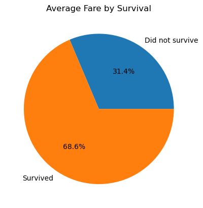

```python
# print the average fare paid by survivors vs non-survivors using a pie chart
df.groupby(["survived"])["fare"].agg("mean").plot.pie(
    autopct='%.1f%%',
    labels=['Did not survive', 'Survived'],
    ylabel='',
    title='Average Fare by Survival'
)

plt.show()
```

```python
# Create a new column for age group
df["age_group"] = df["age"].apply(lambda x: "child" if x < 16 else "adult")

# Calculate survival rate per group
survival_rates = df.groupby("age_group")["survived"].mean()

print(survival_rates)
```

```
age_group
adult    0.36
child    0.59
Name: survived, dtype: float64
```

```python
# find and print the most common port of embarkation
most_common_port = df["embarked"].value_counts().idxmax()
print(f"The most common port of embarkation is: {most_common_port}")
df["embarked"].value_counts()
```

```
The most common port of embarkation is: S
```

```
embarked
S    644
C    168
Q     77
Name: count, dtype: int64
```

```python
# clean the data (e.g., fill or drop missing values in 'age' or 'embarked')
df_cleaned = df.dropna(subset=['age', 'embarked'])
```

```python
# find and print survival rate for children (<16) and adults
df_cleaned.loc[df['age'] < 16, 'is_child'] = True

df_cleaned.groupby('is_child')['survived'].mean()
```

```
is_child
True    0.59
Name: survived, dtype: float64
```